# Literature Synthesis

Group 10 members

4/12/2017

Ryan St.Pierre (ras70) Dakota Brinkman (dlb46) Matt Olson (meo8) Jeremy Schreck (jes85)

# Question 1 - GO Analysis

At first we wanted to familiarize ourselves with the database, shown below.

```r
columns(org.Sc.sgd.db)
```

```
##  [1] "ALIAS"        "COMMON"       "DESCRIPTION"  "ENSEMBL"
##  [5] "ENSEMBLPROT"  "ENSEMBLTRANS" "ENTREZID"     "ENZYME"
##  [9] "EVIDENCE"     "EVIDENCEALL"  "GENENAME"     "GO"
## [13] "GOALL"        "INTERPRO"     "ONTOLOGY"     "ONTOLOGYALL"
## [17] "ORF"          "PATH"         "PFAM"         "PMID"
## [21] "REFSEQ"       "SGD"          "SMART"        "UNIPROT"
```

```r
select(org.Sc.sgd.db, "YAL022C", "ALIAS")
```

```
##       ORF        SGD                                      ALIAS
## 1 YAL022C S000000020 nucleoside transmembrane transporter FUN26
```

### Gene Clustering GO Analysis

Below we pulled in the microarray data and our k-means clustering analysis.

```r
kuang <- read.csv("./datasets/kuang-2014-microarray-expression.csv") ##local- needs to be changed
kuang_t <- as.data.frame(t(kuang[,-1]))
n <- kuang$Gene.name # first remember the names
colnames(kuang_t) <- n
kuang_t.cor <- kuang_t %>% cor(use="pairwise.complete.obs")  ##generate correlation measurements
kuang.dist <- as.dist(1 - kuang_t.cor)  ##use correlation to find distance measurements
kuang.tree <- hclust(kuang.dist, method="complete")
kuang.dend <- as.dendrogram(kuang.tree) ## created & priviewed dendrogram object
k=3
kuang.kmedoids <- pam(kuang.dist, k) # create k-medoids clustering with k clusters
kclusters <- kuang.kmedoids$cluster
kclusters <- kclusters[order.dendrogram(kuang.dend)]
```

```r
kcluster1.genes <- names(kclusters[kclusters == 1])
kcluster2.genes <- names(kclusters[kclusters == 2])
kcluster3.genes <- names(kclusters[kclusters == 3])
length(kcluster1.genes)
```

```
## [1] 2534
```

```r
length(kcluster2.genes)
```

```
## [1] 1593
```

```r
length(kcluster3.genes)
```

```
## [1] 2114
```

In our k-means clustering we only created 3 clusters. We did this to be consistent with the paper. This is described in more detail in our clustering homework. However, in this homework, we just wanted to convey the sizes of our k-means clusters. These clusters are quite large and we decided this was not ideal for GO analysis. We feared that large cluster sizes could lead to clusters with a wide range of functions, which we wanted to avoid for this particular analysis. For this reason, as an alternative, we carry out GO analysis with our hierarchical clusters from the RNASeq data.

# RnaSeq

Below we pulled in the RNASeq data and perform the hierarchical clustering as done in the clustering homework.

```r
rnaseq <- read.csv("./datasets/kuang-2014-rnaseq-expression.csv") #local needs to be changed
rnatime <- read.csv("./datasets/kuang-2014-rnaseq-expression-timepts.csv")
# first remember the names
nrna <- rnaseq$Gene.name

# transpose all but the first column (Gene.name)
rnaseq_t_zeros <- as.data.frame(t(rnaseq[,-1]))
colnames(rnaseq_t_zeros) <- nrna

rnaseq_t_zeros.time <- cbind(rnaseq_t_zeros, time = rnatime$hour)

rnaseq_t <- rnaseq_t_zeros[, colSums(rnaseq_t_zeros != 0) > 0]
rnaseq_t.time <- cbind(rnaseq_t, time = rnatime$hour)

rnaseq.cor <- cor(rnaseq_t, use = "pairwise.complete.obs")
rnaseq.dist <- as.dist(1-rnaseq.cor)

rnaseq.tree <- hclust(rnaseq.dist, method = "complete")
rnaseq.dend <- as.dendrogram(rnaseq.tree)

rnaseq.clusters <- cut(rnaseq.dend, h = 1.9)

rnaseq.clusters.cluster1 <- cut(rnaseq.clusters$lower[[1]], h = 1.5)
rnaseq.clusters.cluster1.clusterAgain <- cut(rnaseq.clusters.cluster1$lower[[1]], h = 1.2)

rnaseq.clusters.cluster2 <- cut(rnaseq.clusters$lower[[2]], h = 1.6)

rnaseq.clusters.cluster3 <- cut(rnaseq.clusters$lower[[3]], h = 1.3)
rnaseq.clusters.cluster3.cutAgain <- cut(rnaseq.clusters.cluster3$lower[[1]], h = .85)

rnaseq.clusters.cluster4 <- cut(rnaseq.clusters$lower[[4]], h = 1.48)
```

In our hierarchical clustering of the RNASeq data we arrived at 18 final clusters. Their names and sizes are listed below.

```r
rnaseq.clusters.cluster1.clusterAgain$lower[[1]]
```

```
## 'dendrogram' with 2 branches and 545 members total, at height 1.095133
```

```r
rnaseq.clusters.cluster1.clusterAgain$lower[[2]]
```

```
## 'dendrogram' with 2 branches and 346 members total, at height 1.117239
```

```r
rnaseq.clusters.cluster2$lower[[1]]
```

```
## 'dendrogram' with 2 branches and 234 members total, at height 1.48567
```

```r
rnaseq.clusters.cluster2$lower[[2]]
```

```
## 'dendrogram' with 2 branches and 188 members total, at height 1.486038
```

```r
rnaseq.clusters.cluster2$lower[[3]]
```

```
## 'dendrogram' with 2 branches and 491 members total, at height 1.396995
```

```r
rnaseq.clusters.cluster2$lower[[4]]
```

```
## 'dendrogram' with 2 branches and 401 members total, at height 1.567286
```

```r
rnaseq.clusters.cluster3.cutAgain$lower[[1]]
```

```
## 'dendrogram' with 2 branches and 265 members total, at height 0.8318486
```

```r
rnaseq.clusters.cluster3.cutAgain$lower[[2]]
```

```
## 'dendrogram' with 2 branches and 567 members total, at height 0.6561431
```

```r
rnaseq.clusters.cluster3.cutAgain$lower[[3]]
```

```
## 'dendrogram' with 2 branches and 47 members total, at height 0.7837043
```

```r
rnaseq.clusters.cluster3.cutAgain$lower[[4]]
```

```
## 'dendrogram' with 2 branches and 254 members total, at height 0.7389783
```

```r
rnaseq.clusters.cluster3.cutAgain$lower[[5]]
```

```
## 'dendrogram' with 2 branches and 374 members total, at height 0.7845916
```

```r
rnaseq.clusters.cluster3$lower[[2]]
```

```
## 'dendrogram' with 2 branches and 24 members total, at height 1.224974
```

```r
rnaseq.clusters.cluster3$lower[[3]]
```

```
## 'dendrogram' with 2 branches and 558 members total, at height 1.268239
```

```r
rnaseq.clusters.cluster4$lower[[1]]
```

```
## 'dendrogram' with 2 branches and 23 members total, at height 1.135677
```

```r
rnaseq.clusters.cluster4$lower[[2]]
```

```
## 'dendrogram' with 2 branches and 528 members total, at height 1.390056
```

```r
rnaseq.clusters.cluster4$lower[[3]]
```

```
## 'dendrogram' with 2 branches and 24 members total, at height 1.282748
```

```r
rnaseq.clusters.cluster4$lower[[4]]
```

```
## 'dendrogram' with 2 branches and 843 members total, at height 1.16056
```

```r
rnaseq.clusters.cluster4$lower[[5]]
```

```
## 'dendrogram' with 2 branches and 431 members total, at height 1.386127
```

*Largest*

```r
rnaseq.clusters.cluster1.clusterAgain$lower[[1]]
```

```
## 'dendrogram' with 2 branches and 545 members total, at height 1.095133
```

```r
rnaseq.clusters.cluster3.cutAgain$lower[[2]]
```

```
## 'dendrogram' with 2 branches and 567 members total, at height 0.6561431
```

```r
rnaseq.clusters.cluster4$lower[[4]]
```

```
## 'dendrogram' with 2 branches and 843 members total, at height 1.16056
```

*Ensure their expression varies*

However, after we chose these clusters we wanted to varify that they contained genes that changed expression over time. In other words we did not want to run GO analysis on clusters with genes whose expression did not vary with time. A cluster with non-variant gene expression would imply that the cluster did not respond to the stress and thus its genes functions are not particularly relevant to the cell’s response to the starvation stress during the metabolic process.

To varify variant expression we plotted the first 5 genes’ expression, in each cluster, over time and observed the results.

```r
rnaseq_t_zeros.time.long <- gather(rnaseq_t_zeros.time, gene, expression, -time);
cols <- c("time", "gene", "expression");
rnaseq_t_zeros.time.long.filtered <- rnaseq_t_zeros.time.long[,cols];
```

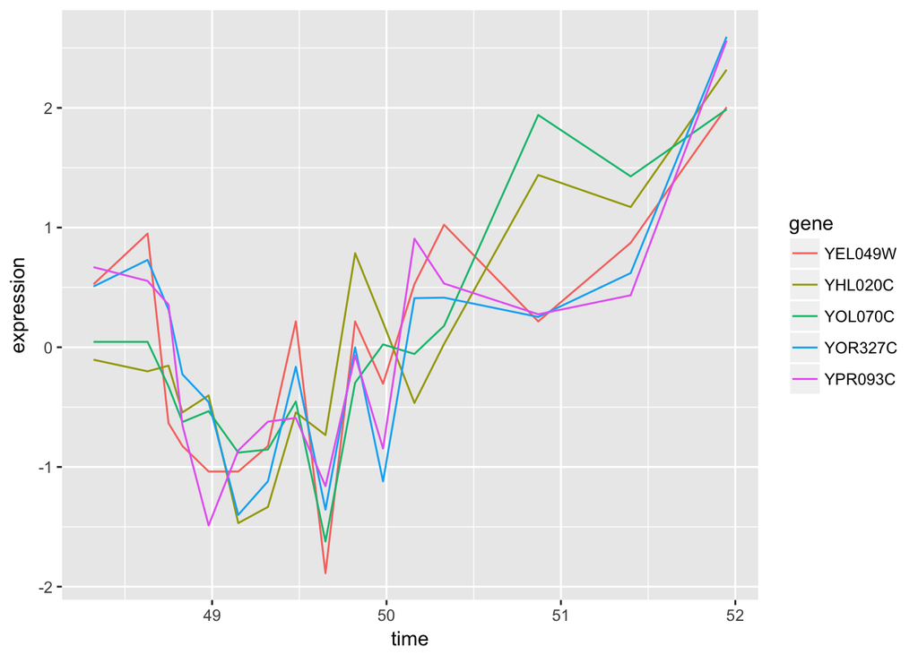

```r
cluster1.genes.names <- as.character(labels(rnaseq.clusters.cluster1.clusterAgain$lower[[1]]))
cluster1.genes.first5 <- cluster1.genes.names[1:5]
rnaseq_t_zeros.time.long.filtered %>%
  filter(gene %in% cluster1.genes.first5) %>%
  ggplot(aes(x = time, y = expression, color = gene)) + geom_line()
```

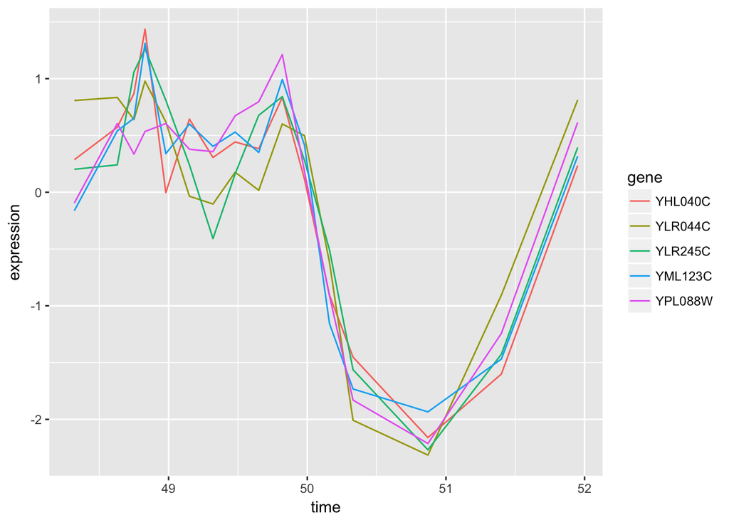

```r
cluster2.genes.names <- as.character(labels(rnaseq.clusters.cluster3.cutAgain$lower[[2]]))
cluster2.genes.first5 <- cluster2.genes.names[1:5]
rnaseq_t_zeros.time.long.filtered %>%
  filter(gene %in% cluster2.genes.first5) %>%
  ggplot(aes(x = time, y = expression, color = gene)) + geom_line()
```

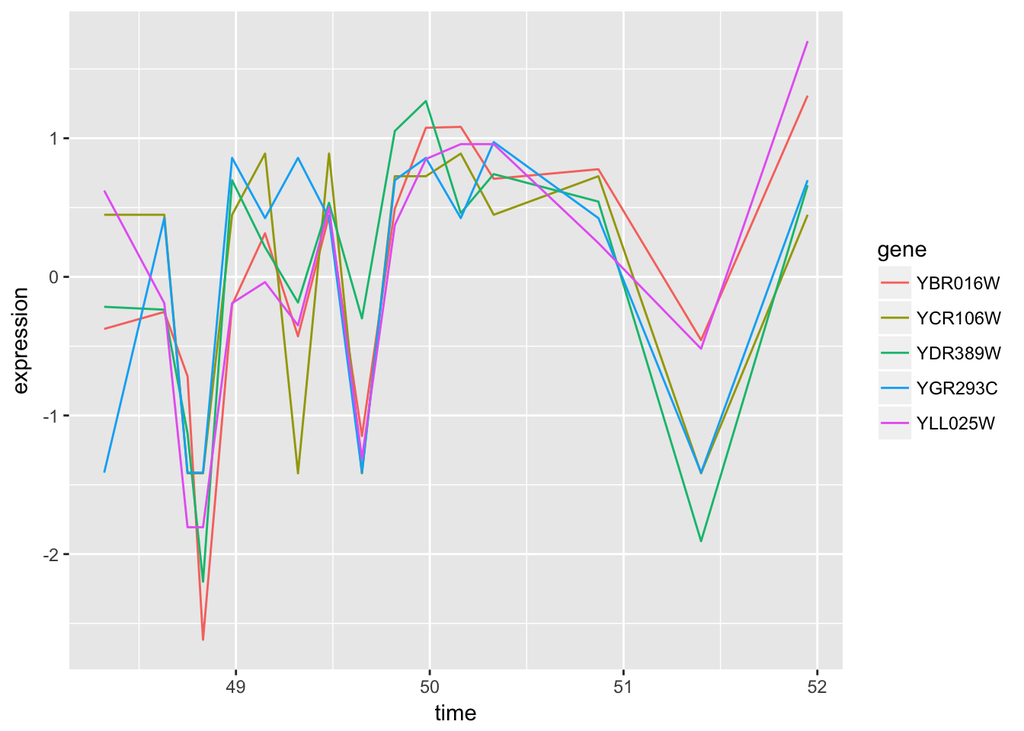

```r
cluster3.genes.names <- as.character(labels(rnaseq.clusters.cluster4$lower[[4]]))
cluster3.genes.first5 <- cluster3.genes.names[1:5]
rnaseq_t_zeros.time.long.filtered %>%
  filter(gene %in% cluster3.genes.first5) %>%
  ggplot(aes(x = time, y = expression, color = gene)) + geom_line()
```

From the plots above it was clear that all three clusters contained genes with variant expression over time. Thus, we decided to continue with these three clusters.

# GO for Hierarchical Clustering

In the following section we carry out the GO analysis for these three clusters.

**P-value cutoff**

At this point we did need to make a decision about what p-value cutoff to use. We used a cutoff of 0.001. It is important to note this cutoff is just a threshold for the *gprofiler* to return results, not a threshold for us to determine significance. Thus, we decided to choose a relatively loose cutoff value for the *gprofiler* and determine the significance of each returned turn retroactively. In this manner we would avoid missing significant terms.

# GO Term Criteria

We had 3 main criteria for chosing which GO terms to investigate further 1. Significant p-values - we wanted to investigate meaningful (low p-value) GO terms 2. Specificity - we wanted to avoid investigating GO terms that were too broad. Since GO terms are organized in a tree structure, we wanted to avoid GO terms “too high up on the tree.” 3. Relevance to paper - we wanted to investigate GO terms that were relevant to the metabolic process or chromatin states. Of course, we didn’t want to limit ourselves from finding discoveries in other areas. However, we also didn’t want to lose our *focus*.

### Cluster 1 - GO Terms

```r
gene.clu <- lapply(rnaseq.clusters.cluster1.clusterAgain$lower, labels)
cluster1.profile <- gprofiler(gene.clu[[1]],
                       organism = "scerevisiae",
                       max_p_value = 0.001,  # set p-value cutoff
                       src_filter = "GO", # consider all processes
                       hier_filtering = "moderate"
                       )
cluster1.profile.sorted <- cluster1.profile[order(cluster1.profile$p.value),] ## sort based on p.value
columns.of.interest <- c(3,4,9,12)
head(cluster1.profile.sorted[,columns.of.interest]) ##make more readable
```

```
##    p.value term.size    term.id                                 term.name
## 5 5.94e-09       186 GO:0032787     monocarboxylic acid metabolic process
## 8 1.80e-08        75 GO:0042579                                 microbody
## 7 1.29e-06       811 GO:0071944                            cell periphery
## 6 1.14e-05       462 GO:0055114               oxidation-reduction process
## 2 2.97e-05        82 GO:0019362     pyridine nucleotide metabolic process
## 3 2.97e-05        82 GO:0046496 nicotinamide nucleotide metabolic process
```

### Cluster 2 - GO Terms

```r
gene.clu2 <- lapply(rnaseq.clusters.cluster3.cutAgain$lower, labels)
cluster2.profile <- gprofiler(gene.clu2[[2]],
                       organism = "scerevisiae",
                       max_p_value = 0.001,  # set p-value cutoff
                       src_filter = "GO", # consider all processes
                       hier_filtering = "moderate"
                       )
cluster2.profile.sorted <- cluster2.profile[order(cluster2.profile$p.value),]
cluster2.profile.sorted[,columns.of.interest] ##make more readable
```

```
##      p.value term.size    term.id                            term.name
## 7  2.90e-103       173 GO:0022626                   cytosolic ribosome
## 3  4.81e-101       187 GO:0002181              cytoplasmic translation
## 11  6.76e-72       233 GO:0003735   structural constituent of ribosome
## 6   6.61e-34       571 GO:0022613 ribonucleoprotein complex biogenesis
## 4   1.11e-21        79 GO:0042255                    ribosome assembly
## 12  2.90e-15      1049 GO:0003723                          RNA binding
## 1   9.66e-12        18 GO:0051029                       rRNA transport
## 2   9.66e-12        18 GO:0006407             rRNA export from nucleus
## 9   4.08e-06        17 GO:0005656      nuclear pre-replicative complex
## 5   4.49e-05        20 GO:0036388     pre-replicative complex assembly
## 8   2.23e-04         6 GO:0042555                          MCM complex
## 10  6.52e-04      2417 GO:0005634                              nucleus
```

### Cluster 3 - GO Terms

```r
gene.clu3 <- lapply(rnaseq.clusters.cluster4$lower, labels)
cluster3.profile <- gprofiler(gene.clu3[[4]],
                       organism = "scerevisiae",
                       max_p_value = 0.001,  # set p-value cutoff
                       src_filter = "GO", # consider all processes
                       hier_filtering = "moderate"
                       )
cluster3.profile.sorted <- cluster3.profile[order(cluster3.profile$p.value),]
head(cluster3.profile.sorted[,columns.of.interest]) ##make more readable
```

```
##     p.value term.size    term.id
## 6  7.67e-19       226 GO:0006511
## 5  1.42e-10       409 GO:0016192
## 15 2.69e-10       172 GO:0007034
## 24 5.83e-10       807 GO:0005515
## 7  1.84e-09      2026 GO:0065007
## 22 2.34e-09      2053 GO:0016020
##                                        term.name
## 6  ubiquitin-dependent protein catabolic process
## 5                     vesicle-mediated transport
## 15                            vacuolar transport
## 24                               protein binding
## 7                          biological regulation
## 22                                      membrane
```

# GO for TF Binding Clusters

Now we carry out GO analysis on clusters we identified in our TF network analyses. Here are steps we did to get our 3 TF clusters (same as in the TF homework):

```r
kuangtf <- read.csv("./datasets/kuang-2014-TFbinding.csv")
time <- read.csv("./datasets/kuang-2014-TFbinding-timepts.csv")
kuangrna <- read.csv("./datasets/kuang-2014-rnaseq-expression.csv")   ##used later - included in the import section of the code for clarity

Gcn <- kuangtf[,c(1:15)]
Esa <- kuangtf[,c(1,16:29)]
Set <- kuangtf[,c(1,30:43)]

Gcn.data <- as.data.frame(t(Gcn[,-1]))
colnames(Gcn.data) <- Gcn$Gene.ID
Gcn.time <- cbind(Gcn.data, time = time$hour)

Esa.data <- as.data.frame(t(Esa[,-1]))
colnames(Esa.data) <- Esa$Gene.ID
Esa.time <- cbind(Esa.data, time = time$hour)

Set.data <- as.data.frame(t(Set[,-1]))
colnames(Set.data) <- Set$Gene.ID
Set.time <- cbind(Set.data, time = time$hour)

#get the genes in the tf and rna data
TF.genes <- unique(kuangtf[,1])
rna.genes <- unique(kuangrna[,1])

#get rid of duplicated rows in the rna data
rna.unique <- unique(kuangrna)

#filter the rna data for the tf genes
rna.Genes <- filter(rna.unique, rna.unique[,1] %in% TF.genes)

#get the unique genes from this rna data
#may not need to do this again but did it just to be safe
rna.genes.u <- unique(rna.Genes[,1])

#It appears that all of the genes present in the TF data are not present in the rna data
#So need to filter again to get rid of these genes
kuangtf.new <- filter(kuangtf, TF.genes %in% rna.genes.u)

#now remove last two columns so the times add up
rna.new <- rna.Genes[,1:15]


#now extract the different TFs
Gcn.new <- kuangtf.new[,c(1:15)]
#dim(Gcn.new)
Esa.new <- kuangtf.new[,c(1,16:29)]
#dim(Esa.new)
Set.new <- kuangtf.new[,c(1,30:43)]
#dim(Set.new)

#here we see the 69 genes that are in the TF data but not the rnaseq
#length(which( ! TF.genes %in% rna.genes))

#sort so that the genes are in the same order
Gcn.sorted <- Gcn.new[match(rna.new[,1], Gcn.new[,1]),]
Esa.sorted <- Esa.new[match(rna.new[,1], Esa.new[,1]),]
Set.sorted <- Set.new[match(rna.new[,1], Set.new[,1]),]
#preview
#head(Gcn.sorted[,1:5])
#head(Esa.sorted[,1:5])
#head(Set.sorted[,1:5])
#head(rna.new[,1:5])
```

```r
##Need to drop gene name
Gcn.sorted.cor <- dplyr::select(Gcn.sorted, -Gene.ID)
Esa.sorted.cor <- dplyr::select(Esa.sorted, -Gene.ID)
Set.sorted.cor <- dplyr::select(Set.sorted, -Gene.ID)
rna.new.cor <- dplyr::select(rna.new, -Gene.name)
corValues.Gcn <- sapply(1:nrow(Gcn.sorted.cor), function(i) cor(as.numeric(Gcn.sorted.cor[i,]), as.numeric(rna.new.cor[i,])))
corValues.Esa <- sapply(1:nrow(Esa.sorted.cor), function(i) cor(as.numeric(Esa.sorted.cor[i,]), as.numeric(rna.new.cor[i,])))
corValues.Set <- sapply(1:nrow(Set.sorted.cor), function(i) cor(as.numeric(Set.sorted.cor[i,]), as.numeric(rna.new.cor[i,])))
df.cors <- data.frame(corValues.Gcn, corValues.Esa, corValues.Set)
#head(df.cors)
```

```r
# But first lets append the gene names to the df.cors dataframe for more informative display
df.cors.w.names <- df.cors
row.names(df.cors.w.names) <- Gcn.sorted$Gene.ID #doesn't matter what set the names comes from - they are all the same
#head(df.cors.w.names)
```

```r
Gcn.indexes <- which(df.cors.w.names[,1] > .75)
Gcn.genes.above <- kuangtf.new[Gcn.indexes, 1]
Esa.indexes <- which(df.cors[,2] > .75)
Esa.genes.above <- kuangtf.new[Esa.indexes, 1]
Set.indexes <- which(df.cors[,3] > .75)
Set.genes.above <- kuangtf.new[Set.indexes, 1]
#print first 10 genes for each TF that meet threshold
#head(df.cors.w.names[Gcn.indexes,1, drop = FALSE], 10)
#head(df.cors.w.names[Esa.indexes,2, drop = FALSE], 10)
#head(df.cors.w.names[Set.indexes,3, drop = FALSE], 10)
```

```r
df.cors["gene"] = Set.sorted["Gene.ID"]
df.cors.single <- df.cors %>%
  tidyr::gather(TF, corr, -gene) %>% # cast to long format
  dplyr::select(TF, gene, corr)
df.cors.single.trimmed <- filter(df.cors.single, corr > 0.75)

gcn <- filter(df.cors.single.trimmed, TF=="corValues.Gcn")
esa <- filter(df.cors.single.trimmed, TF=="corValues.Esa")
set <- filter(df.cors.single.trimmed, TF=="corValues.Set")
```

Now that we have the TF clusters from the previous homework, we can run a GO analysis on each cluster.

### TF Cluster 1: Gcn5

```r
# All GO Terms
columns.of.interest.tf <- c(3,4,9,10,12)
gcn.go <- gprofiler(gcn,
                          organism = "scerevisiae",
                          max_p_value = 0.05,  # set p-value cutoff
                          src_filter = "GO",
                          hier_filtering = "moderate")

gcn.go <- gcn.go[order(gcn.go$p.value),]

gcn.go[,columns.of.interest.tf] ##make more readable
```

```
##    p.value term.size    term.id domain
## 3 2.83e-06        35 GO:0006094     BP
## 5 2.42e-05         9 GO:0000788     CC
## 1 9.84e-05        31 GO:0006096     BP
## 2 9.84e-05        31 GO:0006757     BP
## 4 3.22e-03        27 GO:0031298     CC
## 6 8.35e-03        34 GO:0046982     MF
## 7 3.82e-02        17 GO:0050661     MF
## 8 4.98e-02         3 GO:0043891     MF
##                                                                       term.name
## 3                                                               gluconeogenesis
## 5                                                            nuclear nucleosome
## 1                                                            glycolytic process
## 2                                                       ATP generation from ADP
## 4                                           replication fork protection complex
## 6                                           protein heterodimerization activity
## 7                                                                  NADP binding
## 8 glyceraldehyde-3-phosphate dehydrogenase (NAD(P)+) (phosphorylating) activity
```

MF: protein heterodimerization activity, NADP binding, glyceraldehyde-3-phosphate dehydrogenase (NAD(P)+) (phosphorylating) activity

CC: replication fork protection complex, nuclear nucleosome

### TF Cluster 2: Esa1

```r
esa.go <- gprofiler(esa,
                          organism = "scerevisiae",
                          max_p_value = 0.05,  # set p-value cutoff
                          src_filter = "GO",
                          hier_filtering = "moderate")

esa.go <- esa.go[order(esa.go$p.value),]
esa.go[,columns.of.interest.tf] ##make more readable
```

```
##    p.value term.size    term.id domain               term.name
## 1 0.000794       462 GO:0055085     BP transmembrane transport
## 2 0.007870       111 GO:0045333     BP    cellular respiration
```

Enriched Gene Ontology terms include:

BP: transmembrane transport, cellular respiration

MF: none

CC: none

### TF Cluster 3: Set1

```r
set.go <- gprofiler(set,
                          organism = "scerevisiae",
                          max_p_value = 0.05,  # set p-value cutoff
                          src_filter = "GO",
                          hier_filtering = "moderate")

set.go <- set.go[order(set.go$p.value),]

set.go[,columns.of.interest.tf] ##make more readable
```

```
##     p.value term.size    term.id domain
## 2  3.25e-06       114 GO:0016051     BP
## 7  1.08e-04        35 GO:0019319     BP
## 8  2.53e-04         9 GO:0000788     CC
## 5  1.52e-03       123 GO:0009167     BP
## 1  1.91e-03        31 GO:0006757     BP
## 3  1.91e-03        31 GO:0006096     BP
## 6  2.64e-02         9 GO:0015851     BP
## 9  3.23e-02        27 GO:0031298     CC
## 11 3.76e-02        10 GO:0015205     MF
## 4  4.97e-02         2 GO:0015864     BP
## 10 4.97e-02         2 GO:0000121     MF
## 12 4.97e-02         2 GO:0015214     MF
##                                                   term.name
## 2                         carbohydrate biosynthetic process
## 7                               hexose biosynthetic process
## 8                                        nuclear nucleosome
## 5     purine ribonucleoside monophosphate metabolic process
## 1                                   ATP generation from ADP
## 3                                        glycolytic process
## 6                                      nucleobase transport
## 9                       replication fork protection complex
## 11            nucleobase transmembrane transporter activity
## 4                           pyrimidine nucleoside transport
## 10                          glycerol-1-phosphatase activity
## 12 pyrimidine nucleoside transmembrane transporter activity
```

Enriched Gene Ontology terms include:

BP: pyrimidine nucleoside transport, hexose biosynthetic process, purine ribonucleoside monophosphate metabolic process, ATP generation from ADP, nucleobase transport, carbohydrate biosynthetic process, glycolytic process

MF: pyrimidine nucleoside transmembrane transporter activity, nucleobase transmembrane transporter activity, glycerol-1-phosphatase activity

CC: replication fork protection complex, nuclear nucleosome

# Question 2 - Papers in the literature

## Gene Expression Papers

### Cluster 1 papers

For the first cluster, the gene ontology term with the smallest p-value is **monocarboxylic acid metabolic process**. With a p-value of 5.94e-09, the probability of this term appearing by chances is almost impossible. This is very encouraging because our assigned paper deals with chromatin states across metabolic processes.

Citation: Mota, S., Vieira, N., Barbosa, S., Delaveau, T., Torchet, C., Saux, A. L., . . . Paiva, S. (2014). Role of the DHH1 Gene in the Regulation of Monocarboxylic Acids Transporters Expression in Saccharomyces cerevisiae. PLoS ONE, 9(11). doi:10.1371/journal.pone.0111589

The next term of note that appeared in this cluster is **oxidation-reduction process**. Contrary to what one may infer from the name, oxidation-reduction is a chemical reaction that involves a transfer of electrons between two species. This is related to the three phases of the yeast metabolic cycle: OX (oxidative), RB (reductive building), RC (reductive charging).

Citation: Le Fourn, C., Brasseur, G., Brochier-Armanet, C., Pieulle, L., Brioukhanov, A., Ollivier, B. and Dolla, A. (2011), An oxygen reduction chain in the hyperthermophilic anaerobe Thermotoga maritima highlights horizontal gene transfer between Thermococcales and Thermotogales. Environmental Microbiology, 13: 2132–2145. doi:10.1111/j.1462-2920.2011.02439.x

Piggybacking off of the first gene ontology term for this cluster, the final term of interest is **nicotinamide nucleotide metabolic process**. This term is interesting for its low p-value, as well as its relation to the metabolic process, which is the process of focus of our paper.

Citation: Foster JW, Moat AG. Nicotinamide adenine dinucleotide biosynthesis and pyridine nucleotide cycle metabolism in microbial systems. Microbiological Reviews. 1980;44(1):83-105.

### Cluster 2 papers

With a p-value of 6.76e-72, another gene ontology term of note out of cluster 2 is **structural constituent of ribosome**. The paper by Kuang et al., that is the basis for our project, deals with changes in chromatin status across robust metabolic cycles. It is possibe that the structural consituent of ribosome plays a large role in these chromatic state changes.

Citation: Chen K, Deng S, Lu H, Zheng Y, Yang G, Kim D, et al. (2013) RNA-Seq Characterization of Spinal Cord Injury Transcriptome in Acute/Subacute Phases: A Resource for Understanding the Pathology at the Systems Level. PLoS ONE 8(8): e72567. https://doi.org/10.1371/journal.pone.0072567

Similar to structural constituent of ribosome, the term **ribonucleoprotein complex biogenesis** also appeared for this second cluster with a p-value of 6.61e-34. This is a process that results in the assembly and arrangement of consituent parts of a complex containing RNA and proteins. Chromosomes consist of DNA, so there could be a connection there.

Citation: Dragon, F. et al. A large nucleolar U3 ribonucleoprotein required for 18S ribosomal RNA biogenesis. Nature 417, 967–970 (2002).

### Cluster 3 papers

The first notable term, with the lowest p-value in this cluster, is **ubiquitin-dependent protein catabolic process**. Catabolism is the set of metabolic pathways that breaks down molecules for energy purposes or for other anabolic reactions.

Citation: Dong, Y., Hu, J., Fan, L., & Chen, Q. (2017). RNA-Seq-based transcriptomic and metabolomic analysis reveal stress responses and programmed cell death induced by acetic acid in Saccharomyces cerevisiae. Scientific Reports, 7, 42659. doi:10.1038/srep42659

The next lowest p-value in the third cluster is **vesicle-mediated transport**. This term relates to the transportation of substances in membrane-bound vesicles.

Citation: Vesicle-mediated protein transport: regulatory interactions between the Vps15 protein kinase and the Vps34 PtdIns 3-kinase essential for protein sorting to the vacuole in yeast. The Journal of Cell Biology. 1995;129(2):321-334.

With a p-value of 7.00e-09, **endomembrane system** is very interesting. The endomembrane system regulates protein traffic and, more notably, performs metabolic functions in the cell. Again, we are brougt back to the metabolic process - the focus of our paper.

Citation: Hariri, H., Ugrankar, R., Liu, Y., & Henne, W. M. (2016). Inter-organelle ER-endolysosomal contact sites in metabolism and disease across evolution. Communicative & Integrative Biology, 9(3). doi:10.1080/19420889.2016.1156278

### Re-occuring Terms and Patterns

Metabolism, either directly or indirectly, appears in every cluster. In the first cluster it is the GO term with the lowest p-value. In the second cluster we see many terms dealing with the cytoplasm. After doing more research we found that metabolic processes occur in the cytoplasm. In the third cluster the GO term with the smallest p-value deals with catabolic processes, which is the phase of the metabolic process that distintegrates complex organic compounds to release energy. It is encouraging to see metabolism being repeated in all three clusters because the paper our data comes from is researching chromatin states across metabolic cycles. Therefore it makes sense that genes related to the metabolic process are expressed highly and in all the clusters.

There are no other terms that appear in multiple clusters.

## TF Binding Paper

We found papers for each of the biological process terms in our gene expression clusters, cited earlier. For our TF clusters, we decided to pick the BP term with the lowest p-value out of all the BP terms for all 3 clusters: **gluconeogenesis**. Gluconeogenesis is “a metabolic pathway that results in the generation of glucose from non-carbohydrate carbon substrates such as lactate, glycerol, and glucogenic amino acids”.

Citation: Giménez-Cassina, A., et. al. (2014). Regulation of hepatic energy metabolism and gluconeogenesis by BAD. Cell Metab, 19(2):272-84. doi: 10.1016/j.cmet.2013.12.001.

# Questions 3

Note: in question 2, we provided analysis on each paper that we cited. This section provides a summary of our results.

Do your analyses shed light on how the specific biological processes of interest (identified in the GO analysis above) might be regulated or changed by the stress conditions that your data sets represent?

### Hierarchical Clustering Analysis

The biological processes of interest, identified by GO analysis above may contribute to the oscillations of gene expression under glucose limited conditions. The focal paper discusses the robust metabolic cycles associated with oscillations of gene expression that result from glucose-limited conditions in yeast. Since these terms came up in GO analysis and share similar genes of interest as the kuang data, it is possible that these processes are affected by glucose-limited conditions. A detailed analysis of each of the GO terms is provided below.

**Cluster 1**

ATP to ADP and glycolytic process are general GO terms. However, we chose to include them because we think it provides insight in the cell’s response to glucose starvation. The conversion from ATP to ADP causes a release of energy in the cell. It is understandable that under glucose stress, where energy resources are low, the cell would begin to convert energy as necessary. It is then predictable that genes necessary for this conversion are involved in the GO analysis, as they are expressed under the stress introduced in the paper.

Some of the terms point to information about chromatin states. The chromatin state modifiers correlate to gene expression in the stress response. This suggests that these modifiers manipulate the chromatin state to allow other TFs to activate genes linked to the metabolic process.

**Cluster 2**

The GO terms from cluster 2 relate to cytoplasmic creation, cytoplasmic transport, and RNA. Cluster 2 oscillates. With this information in mind, it makes sense that the material (proteins, cytoplasm) inside the cell is being produced, moved, and used in oscillatory patterns. Cytoplasm, material inside the cell, is necessary for yeast to survive. The yeast cell likely uses resources in the cell when those resources are availabile. However, when there are no other resources remaining, the yeast cell must produce more resources. Ribonucleoprotein complex biogenesis refers to the biosynthesis, assembly, and arrangement of macromolecules containing RNA and proteins. Thus, the yeast cell creates resources when the resources run out and then uses the resources in an oscillatory pattern.

**Cluster 3**

The main terms from this cluster are ubiquitin-dependent protein catabolic process and endomembrane system. Catabolism is the set of metabolic pathways that breaks down molecules for energy purposes or for other anabolic reactions. This clearly relates to the metabolic process. The endomembrane system is a general GO term, but it relates to membranes and cytoplasm which are features of the metabolic process.

### TF Data Analysis

Our focal paper is about the effect of glucose-limited conditions on the metabolic cycle, and the gluconeogenesis paper is about a metabolic pathway that results in the generation of glucose. It makes sense that these papers would be interested in similar sets of genes. The focal paper discusses the robust metabolic cycles associated with oscillations of gene expression that result from glucose-limited conditions in yeast. It would be interesting to explore if gluconeogenesis is one of the metabolic cycles affected by glucose-limited conditions, and if it results in oscillations in the generation of glucose. If this is the case, then it could be a feedback loop where low glucose levels contribute to higher oscillations but higher glucose levels decrease the amount of oscillations.

The other terms in the GO analysis for TF clusters do not seem to be as related to our main paper as terms produced by GO analysis of the hierarchical clusters. The terms in the GO analysis for TF clusters also have higher p-values. For this reason, we decided to focus on the GO terms from the hierarchical cluster analysis.

# Conclusions, Biological Results, & Insights

- Several clusters were identified to have oscillatory expression in response to glucose starvation in the yeast cell.
- These cluster exhibit similar expression patterns that are slightly delayed from each other in time. This suggests that the metabolic process is a complex and highly coordinated process in which there is a “just in time” supply chain.
- GO term analysis revealed terms that related to the metabolic cycle, suggesting that our hierarchical clustering analysis identified at least three clusters particularly responsible for metabolization in the cell.
- Three chromatin state modifiers (Gcn5p, Esa1p and Set1p) were found to have peak binding expression at similar times to gene expression in the stress response. This suggests that these modifiers manipulate the chromatin state to allow other TFs to activate genes linked to metabolization, supporting the conclusion that chromatin state contributes to metabolic processes.

### Comparisson to our Focal Paper

We found similar results to our focal papers, even though our methods varied. Our focal paper found that the metabolic process is a just in time supply chain comparised of several clusters that oscillate in patterns one after the other. The paper breaks down the metabolic process into three phases or clusters: OX, RB, RC. We found a similar result. We found clusters that expressed oscillatory behavior over time, delayed from one another. However, we used several clustering methods. To be consistent with the paper we did a k-means clustering into three clusters. However, we also did hierarchical clustering on the data into 18 clusters. We believe this gave us greater granularity to study the oscillatory patterns. We hope to identify which clusters relate specifically to what phase, and then tie the functionality of these clusters to their phase based on GO terms in our final paper.

Our focal paper seemed to be primarily focused on the gene expression. However, using the TF data we were able to come up with a pipeline that uses a correlation value from gene expression and TF binding to create transcription networks. We found that the chromatin modifiers regulate genes expressed in the stress condition. However, we did not find any complex regulatory patterns or motifs between these three TFs. This is a similar conclusion to the paper.